# Heterogeneity in Oxygen Therapy in ICU

Causal Inference for Health Data - Vignette II

[figure not shown]

## 1 Data Loading

```r
src <- "miiv" # MIMIC-IV dataset in ricu
trt_var <- "oxy_imp" # indicator of supplemental oxygen
out_var <- "po2" # partial pressure of oxygen in arterial blood
```

We load the time series data from MIMIC-IV using the `ricu` package.

```r
dat <- load_concepts(
  c(trt_var, "resp", "po2", "pco2", "sofa", "o2sat", "sex", "age", "fio2"), src,
  verbose = FALSE
)

# subset to first 2 days of ICU stay
dat <- dat[get(index_var(dat)) <= hours(48L) &
           get(index_var(dat)) >= hours(0L)]

# if oxygen indicator indicator is missing, assume the patient is not ventilated
dat[is.na(get(trt_var)), c(trt_var) := FALSE]

# indicate time of first treatment onwards
dat[, is_trt := cummax(get(trt_var)), by = c(id_vars(dat))]

# carry forward imputation for vitals (O2 saturation, respiratoy rate)
dat <- replace_na(dat, type = "locf", by = id_vars(dat),
                  vars = c("o2sat", "resp"))

# impute values in the normal range for missing entries
imp_vals <- list(resp = 18, o2sat = 99, sofa = 0)
for (var in names(imp_vals)) {
  dat[is.na(get(var)), c(var) := imp_vals[[var]]]
}
```

## 2 Selecting Cohort & Generating Data

Selecting all patients with PaO2 reading below 90, before oxygen therapy is initiated.

```r
# select all patients with PaO2 reading below 90 before oxygen is given
cand <- unique(id_col(dat[po2 < 90 & is_trt == 0]))
# subset data to this candidate cohort
cdat <- dat[id_col(dat) %in% cand]
```

Create lag-variables, used for data-processing later.

```r
# lag treatment by 3 hours each way (used for pre- and post- treatment windows)
cdat[, is_trt_lag3 := data.table::shift(is_trt, -3L), by = c(id_vars(cdat))]
cdat[, is_trt_lagrev3 := data.table::shift(is_trt, 3L), by = c(id_vars(cdat))]

# lag treatment by 12 hours (used for controls)
cdat[, is_trt_lag12 := data.table::shift(is_trt, -12L), by = c(id_vars(cdat))]
```

Specify how to perform data aggregation prior to treatment.

```r
# deciding how to aggregate data in
j_expr <- quote(list(
  pco2    = mean_or_na(pco2),
  o2sat   = mean_or_na(o2sat),
  sofa    = max_or_na(sofa),
  resp    = mean_or_na(resp),
  po2     = mean_or_na(po2),
  sex     = unique(sex),
  age     = unique(age)
))
```

Creating the treated cohort.

```r
# treated cohort: PaO2 < 90, and oxygen therapy within 3 hours
trt_coh <- unique(id_col(cdat[is_trt_lag3 == 1 & po2 < 90 & is_trt == 0]))
tdat <- cdat[get(id_var(cdat)) %in% trt_coh]

# for each patient, get PaO2 readings after oxygen therapy is started
post_trt <- tdat[!is.na(po2) & is_trt == 1][, c(id_vars(cdat), out_var), with=FALSE]

# take only the first PaO2 reading after treatment started
post_trt <- post_trt[, head(.SD, n=1L), by = c(id_vars(cdat))]
post_trt <- setnames(post_trt, out_var, "out_post")

trt_dat <- merge(
  # aggregate values 3 hours prior to treatment
  tdat[is_trt == 0 & is_trt_lag3 == 1, eval(j_expr), by = c(id_vars(dat))],
  post_trt
)

# indicate these are the treated cases
trt_dat[, treat := 1]
```

Creating the untreated cohort.

```r
# untreated cohort: treatment not given within 12 hours of PaO2 < 90
ctrls <- cdat[is_trt_lag12 == 0 & po2 < 90 & is_trt == 0]

# of possible times where treatment could have been given, pick one at random
ctrls[, sel_row := sample(.N, 1), by = c(id_vars(ctrls))]
ntrt <- ctrls[, list(charttime=charttime[unique(sel_row)]), by = c(id_vars(ctrls))]
# set the time of non-treament to 1 hour after PaO2 < 90 observed
ntrt[, c(index_var(ntrt)) := get(index_var(ntrt)) + 1]
# indicate that non-treatment starts at this time
ntrt[, non_trt := 1]

# get all time-series data for control cases
ndat <- cdat[(id_col(cdat) %in% id_col(ctrls))]

# merge in control times, where treatment was not given
ndat <- merge(ndat, ntrt, all.x=TRUE)
# for all other times, control was not initiated
ndat[is.na(non_trt), non_trt := 0]

# obtain a cumulative indicator - whether treatment was given previously
ndat[, non_trt := cummax(non_trt), by = c(id_vars(dat))]

# create 3-hour lag for control time
ndat[, is_ntrt_lag3 := data.table::shift(non_trt, -3L), by = c(id_vars(ndat))]

# get all PaO2 measurements after control time
post_ctrl <- ndat[!is.na(po2) & non_trt == 1][, c(id_vars(cdat), out_var), with=FALSE]
# select first PaO2 measurement after control time
post_ctrl <- post_ctrl[, head(.SD, n=1L), by = c(id_vars(post_ctrl))]
post_ctrl <- setnames(post_ctrl, out_var, "out_post")

untrt_dat <- merge(
  # average values in 3 hours prior to control time
  ndat[non_trt == 0 & is_ntrt_lag3 == 1, eval(j_expr), by = c(id_vars(dat))],
  post_ctrl
)

# indicate that these are control cases
untrt_dat <- untrt_dat[, treat := 0]
```

Combining the treated and untreated into a single `data.table`.

```r
res <- rbind(trt_dat, untrt_dat)
res[, sex := ifelse(sex == "Male", 1, 0)]
head(res)
```

| stay_id | pco2 | o2sat | sofa | resp | po2 | sex | age | out_post | treat |
| --- | --- | --- | --- | --- | --- | --- | --- | --- | --- |
| 30002521 | 38.00000 | 84.00000 | 2 | 18.00000 | 55.00000 | 0 | 38 | 145 | 0 |
| 30006067 | 38.00000 | 98.00000 | 4 | 12.66667 | 61.00000 | 1 | 25 | 91 | 0 |
| 30031264 | 40.00000 | 77.00000 | 2 | 18.00000 | 60.00000 | 1 | 59 | 459 | 1 |
| 30033055 | 51.16667 | 76.66667 | 3 | 18.00000 | 60.16667 | 1 | 50 | 166 | 1 |
| 30033143 | 32.00000 | 92.16667 | 8 | 18.33333 | 45.00000 | 1 | 74 | 47 | 0 |
| 30045565 | 31.00000 | 96.66667 | 10 | 17.66667 | 47.00000 | 1 | 68 | 68 | 1 |

## 3 Inspecting Heterogeneity

We fit a causal forest to estimate heterogenous effects.

```r
# fit the causal forest
crf <- causal_forest(
  X = as.matrix(res[, c("pco2", "o2sat", "resp", "po2", "sofa", "sex", "age"),
                    with=FALSE]), # all covariates -- pre-treatment!
  Y = as.numeric(res$out_post), # outcome variable
  W = res$treat # treatment variable
)

# get conditional treatment effects (z-TE) for each row
res[, cate := crf$predictions]
```

### 3.1 TE Measure

We first compute the total effect, which is just the mean of all z-specific effects

$$\hat{\text{TE}}_{x_0, x_1}(y) = \frac{1}{n} \sum_{i=1}^n
\hat{z\text{-TE}}_{x_0, x_1}(y\mid z_i)$$

```r
res[, mean(cate)]
```

```
## [1] 29.52673
```

### 3.2 ETT

We next look at the effect of treatment on the treated (ETT). We first compare the treated and untreated populations.

#### 3.2.1 Comparing the treated and untreated groups

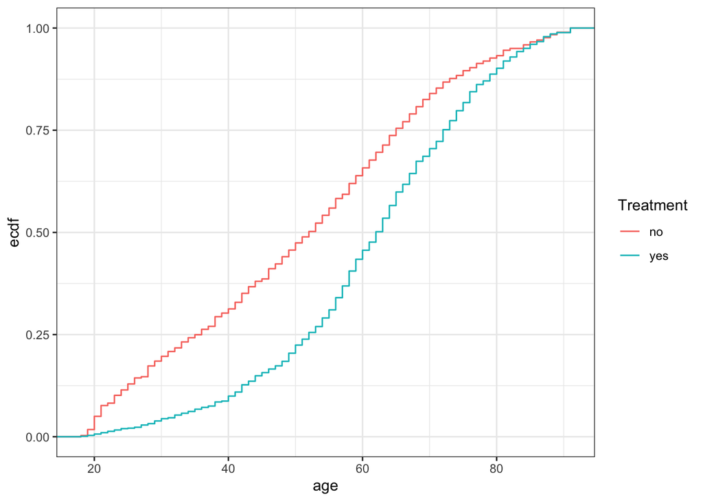

```r
# compare the age distribution - what is the conclusion?
ggplot(res, aes(x = age, color = factor(treat))) +
  stat_ecdf() + theme_bw() +
  scale_color_discrete(name = "Treatment", labels = c("no", "yes"))
```

We conclude that patients that are treated are *older* on average.

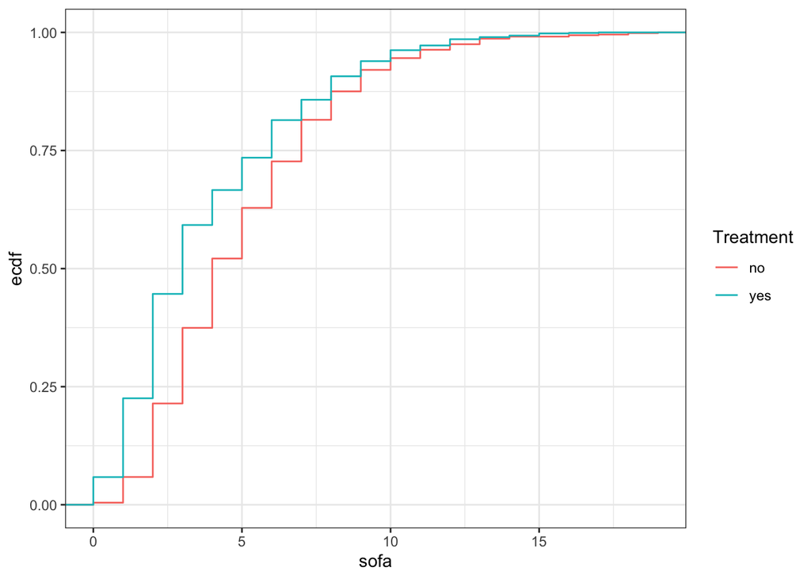

```r
# compare the SOFA score distribution - what is the conclusion?
ggplot(res, aes(x = sofa, color = factor(treat))) +
  stat_ecdf() + theme_bw() +
  scale_color_discrete(name = "Treatment", labels = c("no", "yes"))
```

We conclude that patients that are treated have *lower* SOFA scores on average.

#### 3.2.2 ETT computation

Provided the set of covariates $Z$ is back-door for $(X, Y)$, the ETT can be computed as:

$$\hat{\text{ETT}}_{x_0, x_1}(y \mid x) = \frac{1}{n} \sum_{i: X_i=x}
\hat{z\text{-TE}}_{x_0, x_1}(y\mid z_i)$$

```r
etts <- res[, list(ett = mean(cate)), by = "treat"]
etts
```

| treat | ett |
| --- | --- |
| 0 | 30.08737 |
| 1 | 29.10486 |

For the treated, PaO2 increases by 29.1 following treatment. For the unreated, PaO2 increases by 30.1 following treatment.

We next look at conditional effects to better understand this difference.

### 3.3 z-TE(s)

Inspecting heterogeneity according to SOFA.

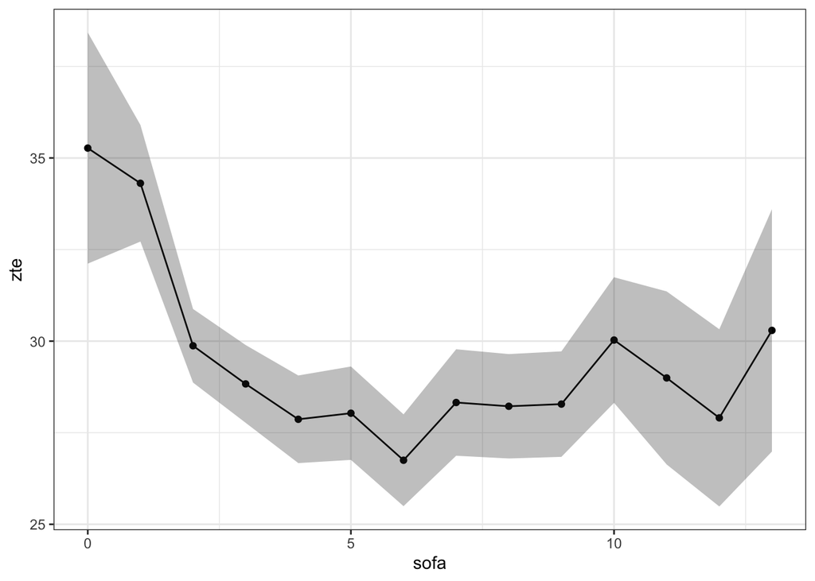

```r
sofa_te <- res[, list(zte = mean(cate), dev = sd(cate) / sqrt(.N), cnt = .N),
               by = c("sofa")]

ggplot(sofa_te[cnt > 10], aes(x = sofa, y = zte)) +
  geom_point() + theme_bw() + theme_bw() + geom_line() +
  geom_ribbon(aes(ymin=zte - 1.96 * dev, ymax = zte + 1.96 * dev), alpha = 0.3)
```

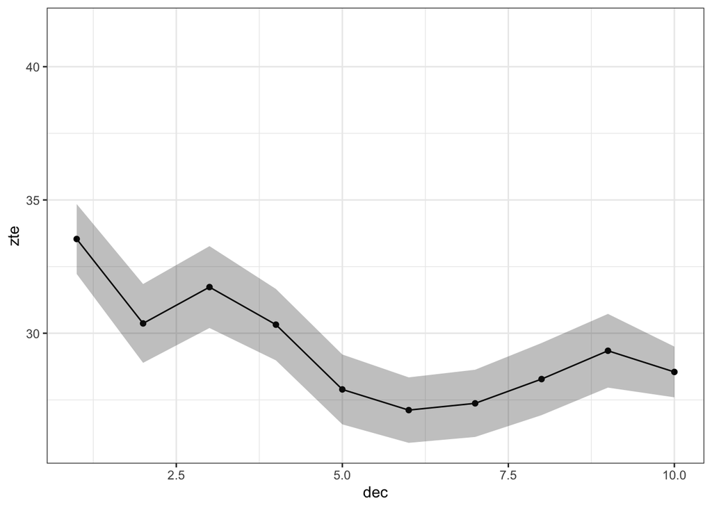

```r
decile_heterogeneity <- function(var, res) {

  res[, dec := .bincode(get(var), quantile(get(var), seq(0, 1, 0.1)))]
  z_te <- res[, list(zte = mean(cate), dev = sd(cate) / sqrt(.N), cnt = .N),
              by = c("dec")]
  ggplot(z_te, aes(x = dec, y = zte)) +
    geom_point() + theme_bw() + geom_line() +
    geom_ribbon(aes(ymin=zte - 1.96 * dev, ymax = zte + 1.96 * dev), alpha = 0.3)
}

decile_heterogeneity("age", res)
```

How do we explain this heterogeneity? Provide two reasons.